# Problem Set 06

WRITE YOUR NAME HERE

WRITE DATE HERE

## Background

We will again use the hate crimes data we used in Problem Set 05. The FiveThirtyEight article article about those data are in the Jan 23, 2017 [“Higher Rates Of Hate Crimes Are Tied To Income Inequality”](https://fivethirtyeight.com/features/higher-rates-of-hate-crimes-are-tied-to-income-inequality/). This week, we will use these data to run regression models with a single categorical predictor (explanatory) variable **and** a single numeric predictor (explanatory) variable.

Remember you can knit this file to see the instructions. You can type your answers again right into this file, knit the final draft with all your answers. Please submit the `html` file on Moodle.

## Setup

First load the necessary packages

```r
library(ggplot2)
library(dplyr)
library(moderndive)
library(readr)
```

```r
hate_crimes <- read_csv("http://bit.ly/2ItxYg3")
```

Next let’s explore the `hate_crimes` data set using the `glimpse()` function from the `dplyr` package:

```r
glimpse(hate_crimes)
```

You should also take a look at the data in the **data viewer**.

Each case/row in these data is a state in the US. This week we will consider the response variable `income`, which is the numeric variable of median income of households in each state.

We will use the following categorical explanatory variables:

- `trump_support`: level of Trump support in 2016 election (low, medium or high)
- `unemployment`: level of unemployment in a state (low or high)
- `urbanization`: level of urbanization in a region ()

And we will consider the following numerical explanatory variable:

- `share_pop_hs`: the percentage of adults 25 and older with a high school degree

## Income, education and urbanization

Let’s start by modeling the relationship between:

- $y$: Median household income in 2016
- $x_1$: numerical variable percent of adults 25 and older with a high-school degree, contained in the `hs` variable
- $x_2$: categorical variable level of urbanization in a state: `low`, or `high`, as contained in the variable `urbanization`

# Question 1

Create a scatterplot showing:

- Median household `income` on the $y$ axis
- Percent of adults 25 or older with a high school degree on the $x$ axis
- The points colored by the variable `urbanization`
- A line of best fit (regression line) for each level of the variable `urbanization` (one for “low”, one for “high”)

Please include axis labels and and title.

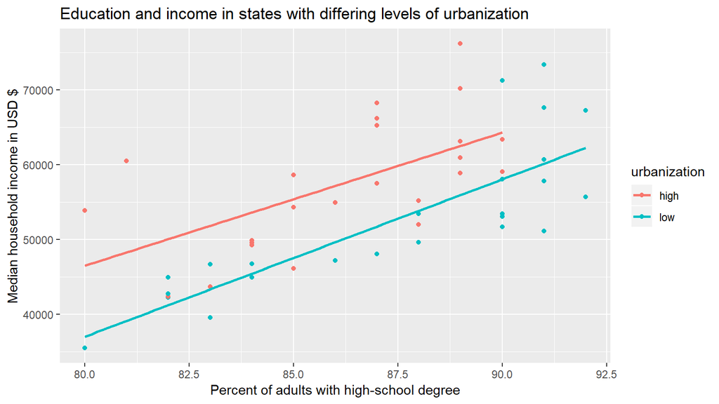

```r
ggplot(data = hate_crimes, aes(y = income, x = hs, color = urbanization)) +
  geom_point()+
  geom_smooth(method = "lm", se = F) +
  labs(
    x = "Percent of adults with high-school degree",
    y = "Median household income in USD $",
    title = "Education and income in states with differing levels of urbanization"
  )
```

# Question 2.A

Do you think the relationship between `hs` and `income` is strong or weak, linear or non-linear?

**Answer:** Fairly strong, linear relationship

# Question 2.B

Does the slope look fairly similar for the two levels of urbanization?

**Answer:** Yes

# Question 2.B

Which regression line (high `urbanization` or low `urbanization`) appears to have the larger intercept?

**Answer:** high urbanization